# Risk Factor Analysis

## Outcome Variable

**Outcome Variable:** ever_sstunted

## Predictor Variables

**Intervention Variable:** fhtcm

**Adjustment Set:**

- arm
- W_mage
- W_fage
- meducyrs
- feducyrs
- W_mhtcm
- W_mwtkg
- W_mbmi
- single
- delta_W_mage
- delta_W_fage
- delta_meducyrs
- delta_feducyrs
- delta_W_mhtcm
- delta_W_mwtkg
- delta_W_mbmi
- delta_single

## Stratifying Variables

The analysis was stratified on these variable(s):

- agecat
- studyid
- country

## Data Summary

| agecat | studyid | country | fhtcm | ever_sstunted | n_cell | n |
| --- | --- | --- | --- | --- | --- | --- |
| 0-24 months | COHORTS | GUATEMALA | >=167 cm | 0 | 37 | 496 |
| 0-24 months | COHORTS | GUATEMALA | >=167 cm | 1 | 27 | 496 |
| 0-24 months | COHORTS | GUATEMALA | <162 cm | 0 | 103 | 496 |
| 0-24 months | COHORTS | GUATEMALA | <162 cm | 1 | 190 | 496 |
| 0-24 months | COHORTS | GUATEMALA | [162-167) cm | 0 | 77 | 496 |
| 0-24 months | COHORTS | GUATEMALA | [162-167) cm | 1 | 62 | 496 |
| 0-24 months | Keneba | GAMBIA | >=167 cm | 0 | 972 | 1929 |
| 0-24 months | Keneba | GAMBIA | >=167 cm | 1 | 273 | 1929 |
| 0-24 months | Keneba | GAMBIA | <162 cm | 0 | 98 | 1929 |
| 0-24 months | Keneba | GAMBIA | <162 cm | 1 | 34 | 1929 |
| 0-24 months | Keneba | GAMBIA | [162-167) cm | 0 | 413 | 1929 |
| 0-24 months | Keneba | GAMBIA | [162-167) cm | 1 | 139 | 1929 |
| 0-24 months | PROBIT | BELARUS | >=167 cm | 0 | 11452 | 12537 |
| 0-24 months | PROBIT | BELARUS | >=167 cm | 1 | 292 | 12537 |
| 0-24 months | PROBIT | BELARUS | <162 cm | 0 | 154 | 12537 |
| 0-24 months | PROBIT | BELARUS | <162 cm | 1 | 14 | 12537 |
| 0-24 months | PROBIT | BELARUS | [162-167) cm | 0 | 597 | 12537 |
| 0-24 months | PROBIT | BELARUS | [162-167) cm | 1 | 28 | 12537 |
| 0-24 months | SAS-CompFeed | INDIA | >=167 cm | 0 | 307 | 907 |
| 0-24 months | SAS-CompFeed | INDIA | >=167 cm | 1 | 103 | 907 |
| 0-24 months | SAS-CompFeed | INDIA | <162 cm | 0 | 130 | 907 |
| 0-24 months | SAS-CompFeed | INDIA | <162 cm | 1 | 100 | 907 |
| 0-24 months | SAS-CompFeed | INDIA | [162-167) cm | 0 | 159 | 907 |
| 0-24 months | SAS-CompFeed | INDIA | [162-167) cm | 1 | 108 | 907 |
| 0-24 months | SAS-FoodSuppl | INDIA | >=167 cm | 0 | 62 | 399 |
| 0-24 months | SAS-FoodSuppl | INDIA | >=167 cm | 1 | 44 | 399 |
| 0-24 months | SAS-FoodSuppl | INDIA | <162 cm | 0 | 69 | 399 |
| 0-24 months | SAS-FoodSuppl | INDIA | <162 cm | 1 | 94 | 399 |
| 0-24 months | SAS-FoodSuppl | INDIA | [162-167) cm | 0 | 72 | 399 |
| 0-24 months | SAS-FoodSuppl | INDIA | [162-167) cm | 1 | 58 | 399 |

The following strata were considered:

- agecat: 0-24 months, studyid: COHORTS, country: GUATEMALA
- agecat: 0-24 months, studyid: Keneba, country: GAMBIA
- agecat: 0-24 months, studyid: PROBIT, country: BELARUS
- agecat: 0-24 months, studyid: SAS-CompFeed, country: INDIA
- agecat: 0-24 months, studyid: SAS-FoodSuppl, country: INDIA

## Methods Detail

We're interested in the causal parameters $E[Y_a]$ for all values of $a \in \mathcal{A}$. These parameters represent the mean outcome if, possibly contrary to fact, we intervened to set all units to have $A=a$. Under the randomization and positivity assumptions, these are identified by the statistical parameters $\psi_a=E_W[E_{Y|A,W}(Y|A=a,W)]$. In addition, we're interested in the mean of $Y$, $E[Y]$ under no intervention (the observed mean). We will estimate these parameters by using SuperLearner to fit the relevant likelihood factors -- $E_{Y|A,W}(Y|A=a,W)$ and $p(A=a|W)$, and then updating our likelihood fit using a joint TMLE.

For unadjusted analyses ($W=\{\}$), initial likelihoods were estimated using Lrnr_glm to estimate the simple $E(Y|A)$ and Lrnr_mean to estimate $p(A)$. For adjusted analyses, a small library containing Lrnr_glmnet, Lrnr_xgboost, and Lrnr_mean was used.

Having estimated these parameters, we will then use the delta method to estimate relative risks and attributable risks relative to a prespecified baseline level of $A$.

# Results Detail

## Results Plots

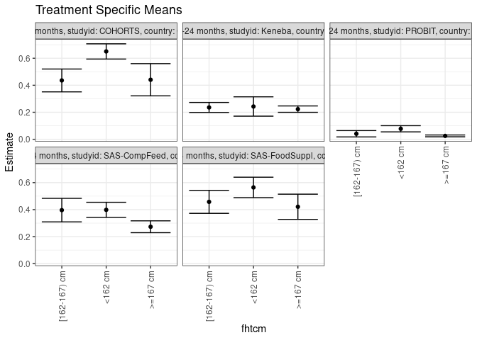

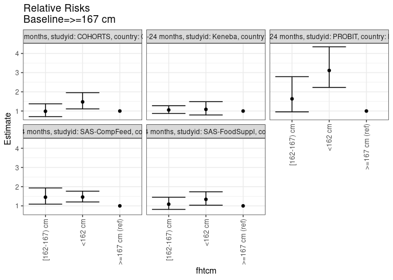

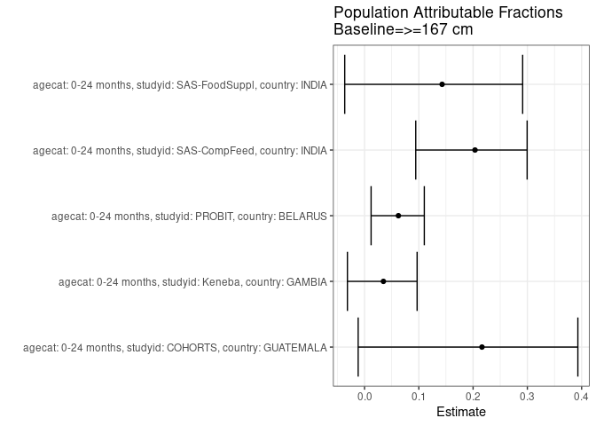

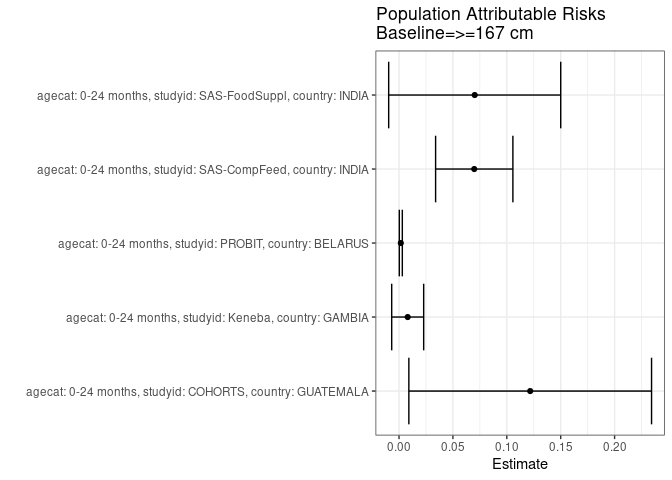

## Results Table

### Parameter: TSM

| agecat | studyid | country | intervention_level | baseline_level | estimate | ci_lower | ci_upper |
| --- | --- | --- | --- | --- | --- | --- | --- |
| 0-24 months | COHORTS | GUATEMALA | >=167 cm | NA | 0.4407928 | 0.3215581 | 0.5600274 |
| 0-24 months | COHORTS | GUATEMALA | <162 cm | NA | 0.6503521 | 0.5940406 | 0.7066636 |
| 0-24 months | COHORTS | GUATEMALA | [162-167) cm | NA | 0.4355883 | 0.3509782 | 0.5201983 |
| 0-24 months | Keneba | GAMBIA | >=167 cm | NA | 0.2231679 | 0.1994719 | 0.2468638 |
| 0-24 months | Keneba | GAMBIA | <162 cm | NA | 0.2427016 | 0.1710586 | 0.3143447 |
| 0-24 months | Keneba | GAMBIA | [162-167) cm | NA | 0.2356439 | 0.1986263 | 0.2726616 |
| 0-24 months | PROBIT | BELARUS | >=167 cm | NA | 0.0249793 | 0.0182788 | 0.0316799 |
| 0-24 months | PROBIT | BELARUS | <162 cm | NA | 0.0777379 | 0.0547699 | 0.1007059 |
| 0-24 months | PROBIT | BELARUS | [162-167) cm | NA | 0.0408351 | 0.0173468 | 0.0643234 |
| 0-24 months | SAS-CompFeed | INDIA | >=167 cm | NA | 0.2730944 | 0.2292081 | 0.3169807 |
| 0-24 months | SAS-CompFeed | INDIA | <162 cm | NA | 0.3982028 | 0.3419936 | 0.4544120 |
| 0-24 months | SAS-CompFeed | INDIA | [162-167) cm | NA | 0.3962731 | 0.3092057 | 0.4833405 |
| 0-24 months | SAS-FoodSuppl | INDIA | >=167 cm | NA | 0.4210162 | 0.3277284 | 0.5143039 |
| 0-24 months | SAS-FoodSuppl | INDIA | <162 cm | NA | 0.5642176 | 0.4884770 | 0.6399583 |
| 0-24 months | SAS-FoodSuppl | INDIA | [162-167) cm | NA | 0.4575611 | 0.3723694 | 0.5427528 |

### Parameter: E(Y)

| agecat | studyid | country | intervention_level | baseline_level | estimate | ci_lower | ci_upper |
| --- | --- | --- | --- | --- | --- | --- | --- |
| 0-24 months | COHORTS | GUATEMALA | NA | NA | 0.5625000 | 0.5187986 | 0.6062014 |
| 0-24 months | Keneba | GAMBIA | NA | NA | 0.2312079 | 0.2123887 | 0.2500270 |
| 0-24 months | PROBIT | BELARUS | NA | NA | 0.0266411 | 0.0195656 | 0.0337167 |
| 0-24 months | SAS-CompFeed | INDIA | NA | NA | 0.3428886 | 0.3091585 | 0.3766188 |
| 0-24 months | SAS-FoodSuppl | INDIA | NA | NA | 0.4912281 | 0.4421136 | 0.5403426 |

### Parameter: RR

| agecat | studyid | country | intervention_level | baseline_level | estimate | ci_lower | ci_upper |
| --- | --- | --- | --- | --- | --- | --- | --- |
| 0-24 months | COHORTS | GUATEMALA | >=167 cm | >=167 cm | 1.0000000 | 1.0000000 | 1.000000 |
| 0-24 months | COHORTS | GUATEMALA | <162 cm | >=167 cm | 1.4754145 | 1.1123573 | 1.956968 |
| 0-24 months | COHORTS | GUATEMALA | [162-167) cm | >=167 cm | 0.9881928 | 0.7093363 | 1.376674 |
| 0-24 months | Keneba | GAMBIA | >=167 cm | >=167 cm | 1.0000000 | 1.0000000 | 1.000000 |
| 0-24 months | Keneba | GAMBIA | <162 cm | >=167 cm | 1.0875294 | 0.7952758 | 1.487183 |
| 0-24 months | Keneba | GAMBIA | [162-167) cm | >=167 cm | 1.0559044 | 0.8741976 | 1.275380 |
| 0-24 months | PROBIT | BELARUS | >=167 cm | >=167 cm | 1.0000000 | 1.0000000 | 1.000000 |
| 0-24 months | PROBIT | BELARUS | <162 cm | >=167 cm | 3.1120883 | 2.2297127 | 4.343651 |
| 0-24 months | PROBIT | BELARUS | [162-167) cm | >=167 cm | 1.6347557 | 0.9579478 | 2.789741 |
| 0-24 months | SAS-CompFeed | INDIA | >=167 cm | >=167 cm | 1.0000000 | 1.0000000 | 1.000000 |
| 0-24 months | SAS-CompFeed | INDIA | <162 cm | >=167 cm | 1.4581139 | 1.2036674 | 1.766349 |
| 0-24 months | SAS-CompFeed | INDIA | [162-167) cm | >=167 cm | 1.4510480 | 1.0894619 | 1.932642 |
| 0-24 months | SAS-FoodSuppl | INDIA | >=167 cm | >=167 cm | 1.0000000 | 1.0000000 | 1.000000 |
| 0-24 months | SAS-FoodSuppl | INDIA | <162 cm | >=167 cm | 1.3401329 | 1.0359731 | 1.733594 |
| 0-24 months | SAS-FoodSuppl | INDIA | [162-167) cm | >=167 cm | 1.0868017 | 0.8155974 | 1.448187 |

### Parameter: PAR

| agecat | studyid | country | intervention_level | baseline_level | estimate | ci_lower | ci_upper |
| --- | --- | --- | --- | --- | --- | --- | --- |
| 0-24 months | COHORTS | GUATEMALA | >=167 cm | NA | 0.1217072 | 0.0091244 | 0.2342900 |
| 0-24 months | Keneba | GAMBIA | >=167 cm | NA | 0.0080400 | -0.0067956 | 0.0228756 |
| 0-24 months | PROBIT | BELARUS | >=167 cm | NA | 0.0016618 | 0.0002643 | 0.0030593 |
| 0-24 months | SAS-CompFeed | INDIA | >=167 cm | NA | 0.0697942 | 0.0339433 | 0.1056452 |
| 0-24 months | SAS-FoodSuppl | INDIA | >=167 cm | NA | 0.0702119 | -0.0095953 | 0.1500191 |

### Parameter: PAF

| agecat | studyid | country | intervention_level | baseline_level | estimate | ci_lower | ci_upper |
| --- | --- | --- | --- | --- | --- | --- | --- |
| 0-24 months | COHORTS | GUATEMALA | >=167 cm | NA | 0.2163684 | -0.0117611 | 0.3930598 |
| 0-24 months | Keneba | GAMBIA | >=167 cm | NA | 0.0347739 | -0.0315701 | 0.0968511 |
| 0-24 months | PROBIT | BELARUS | >=167 cm | NA | 0.0623773 | 0.0120798 | 0.1101141 |
| 0-24 months | SAS-CompFeed | INDIA | >=167 cm | NA | 0.2035478 | 0.0943480 | 0.2995807 |
| 0-24 months | SAS-FoodSuppl | INDIA | >=167 cm | NA | 0.1429314 | -0.0365377 | 0.2913267 |